# Practice with Rjags

Victor Feagins

6/4/2021

# Packages —-

```r
library(rjags) #Uses JAGS to create bayesian models
library(coda)
library(tidyverse) #Utility functions
```

# Functions —-

```r
set.seed(123)
Examine <- function(vector){
  #To examine the variable to grab info from it
  H <- head(vector)
  C <- class(vector)
  S <- summary(vector)
  M <- sum(is.na(vector))
  D <- sum(duplicated(vector))
  print("First 6 obs")
  print(H)
  print(S)
  print(paste("Class ", C))
  print(paste("Missing ", M))
  print(paste("Duplicates", D))

}
ScatterPlot <- function(data, x, y){
  ggplot(data, mapping = aes(x, y))+
    geom_point()+
    geom_smooth() +
    xlab(deparse(substitute(x)))+
    ylab(deparse(substitute(y)))
}
```

# Classical Modeling —-

The following will be a typical modeling situation. Fitting a linear regression with continuous variables the data set I will be using is the Auto dataset from the ISLR package

## Data —-

```r
df.A <- ISLR::Auto #A dataset that contains various variables related to cars

attach(df.A) #This allows me to avoid writing the df.A$ notation and can call variables as is
```

## Exploring Data —-

With the Auto dataset we will try to model Miles per gallon (mpg) for a car.

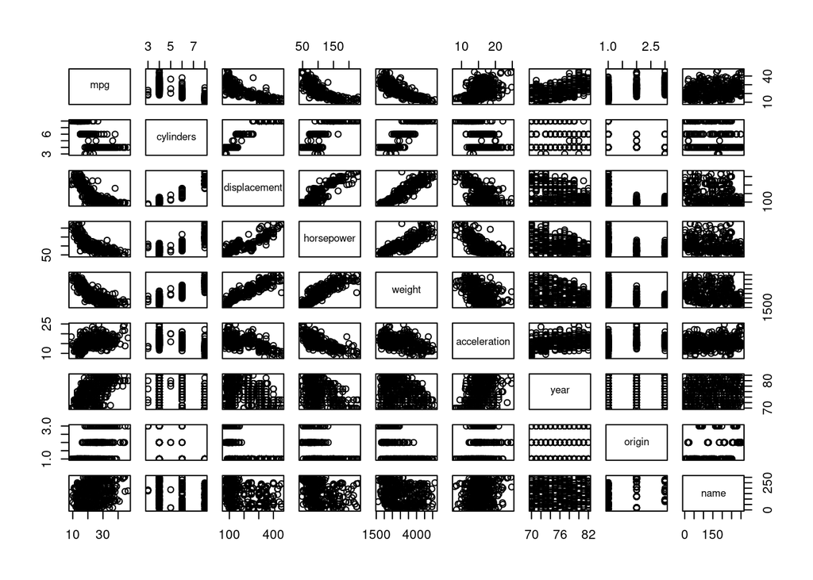

```r
pairs(df.A) #Get a glimpse of the behavior of the data
```

We can see that there are variables that seem to have a linear relationship with mpg. Mainly displacement, horsepower, and weight. We will focus on these variables.

### mpg —-

miles per gallon

```r
Examine(mpg)
```

```
## [1] "First 6 obs"
## [1] 18 15 18 16 17 15
##    Min. 1st Qu.  Median    Mean 3rd Qu.    Max.
##    9.00   17.00   22.75   23.45   29.00   46.60
## [1] "Class  numeric"
## [1] "Missing  0"
## [1] "Duplicates 265"
```

We can see no missing data. The range is 9 - 46.60 with a mean of 23.45

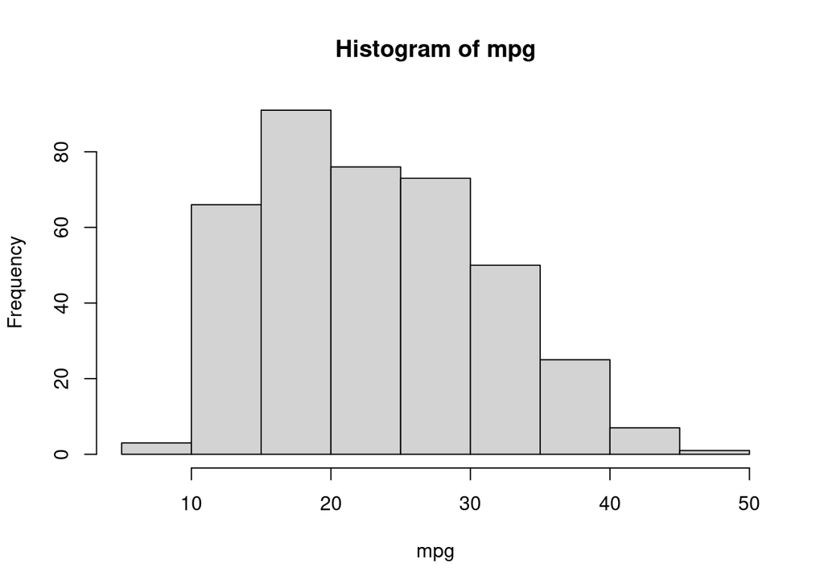

```r
hist(mpg)
```

In the histogram we see the data seems to have right skewness

### displacement —-

Engine displacement (cu. inches)

```r
Examine(displacement)
```

```
## [1] "First 6 obs"
## [1] 307 350 318 304 302 429
##    Min. 1st Qu.  Median    Mean 3rd Qu.    Max.
##    68.0   105.0   151.0   194.4   275.8   455.0
## [1] "Class  numeric"
## [1] "Missing  0"
## [1] "Duplicates 311"
```

No missing data. The range is 68 - 455 with a mean of 194.4

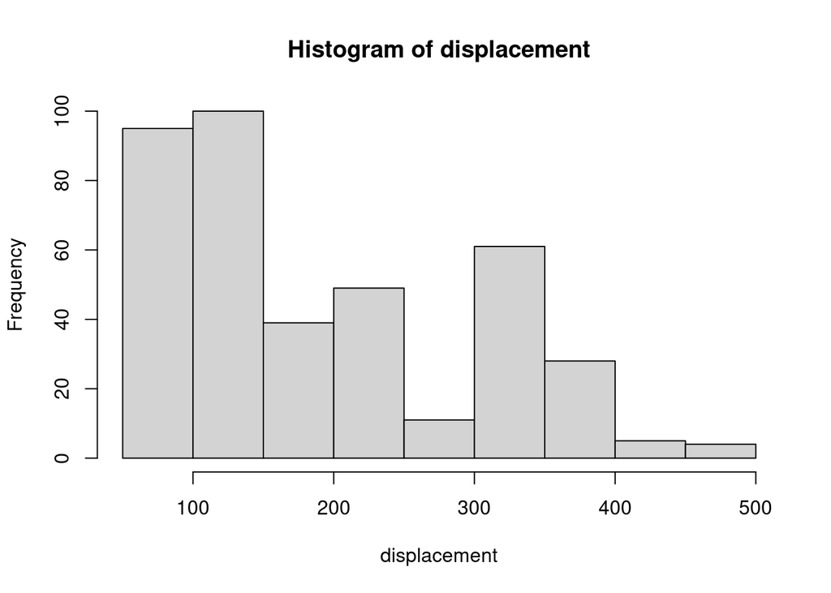

```r
hist(displacement)
```

Very right skewed

#### Relationship displacement —-

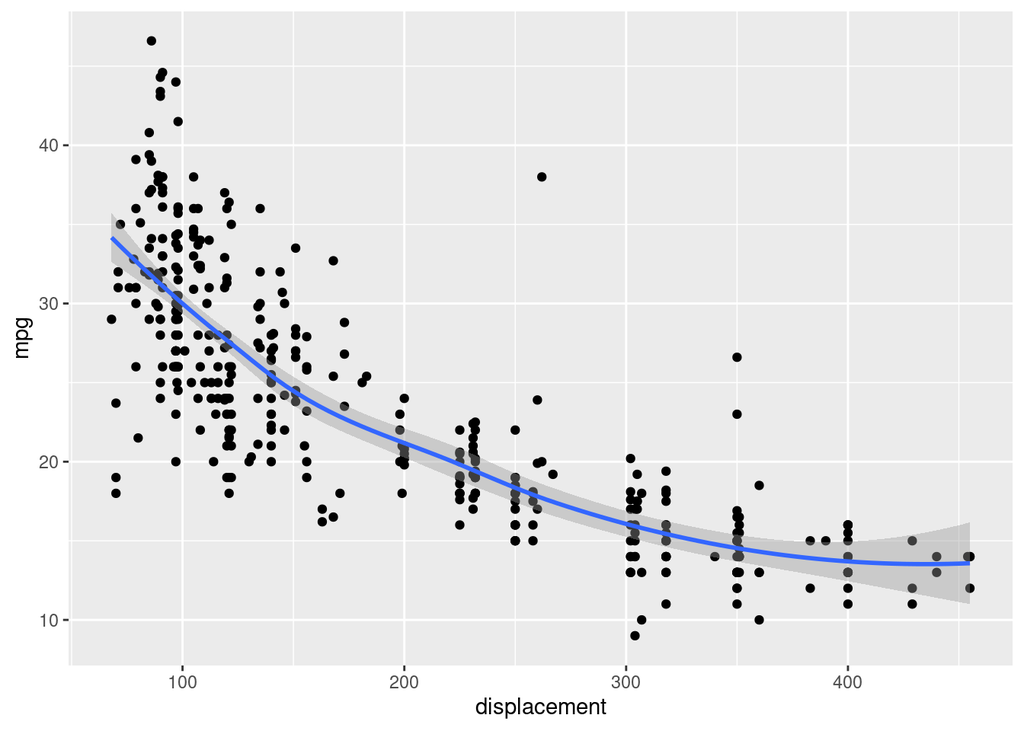

```r
ScatterPlot(data = df.A, x = displacement, y = mpg)
```

```r
cor(displacement, mpg)
```

```
## [1] -0.8051269
```

The relationship between displacement and mpg is negative and not linear.

### horsepower —-

```r
#Engine horsepower
Examine(horsepower)
```

```
## [1] "First 6 obs"
## [1] 130 165 150 150 140 198
##    Min. 1st Qu.  Median    Mean 3rd Qu.    Max.
##    46.0    75.0    93.5   104.5   126.0   230.0
## [1] "Class  numeric"
## [1] "Missing  0"
## [1] "Duplicates 299"
```

No missings. Ranges 46 - 230 with a mean of 104.

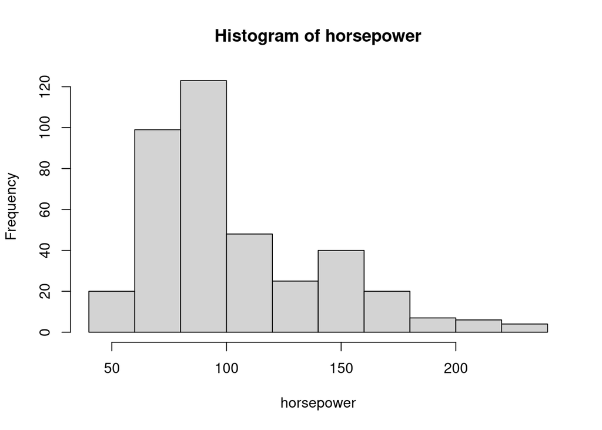

```r
hist(horsepower)
```

Again right skewed

#### Relationship horsepower —-

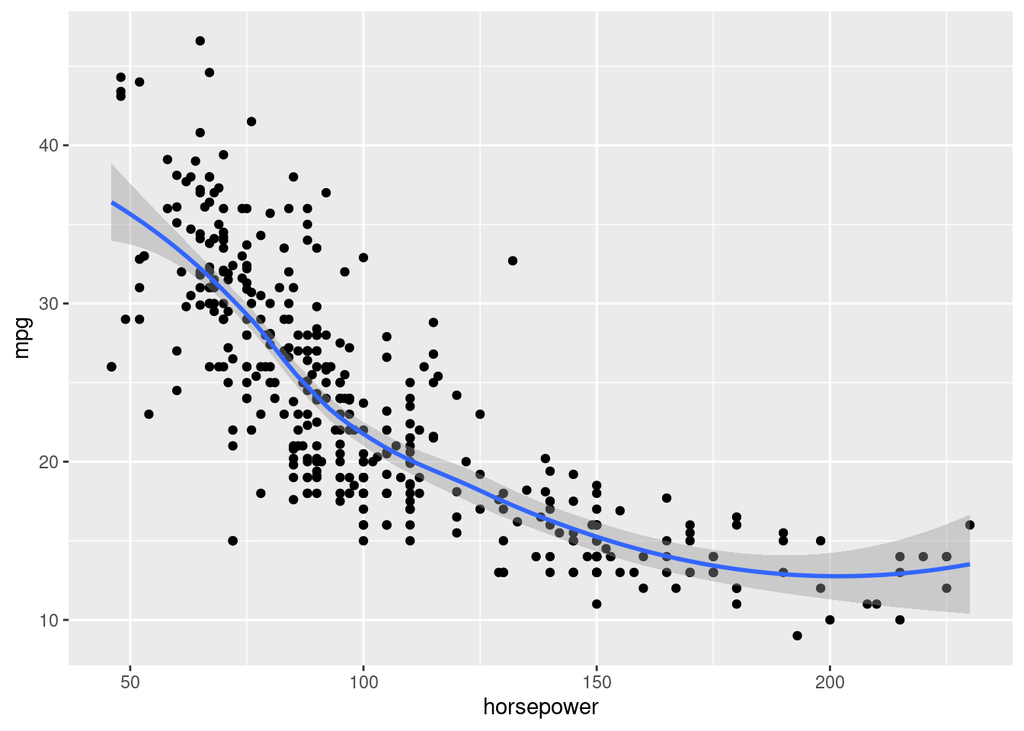

```r
ScatterPlot(df.A, horsepower, mpg)
```

```r
cor(horsepower, mpg)
```

```
## [1] -0.7784268
```

The relationship between horsepower and mpg is negative and not linear.

### weight —-

Vehicle weight (lbs.)

```r
Examine(weight)
```

```
## [1] "First 6 obs"
## [1] 3504 3693 3436 3433 3449 4341
##    Min. 1st Qu.  Median    Mean 3rd Qu.    Max.
##    1613    2225    2804    2978    3615    5140
## [1] "Class  numeric"
## [1] "Missing  0"
## [1] "Duplicates 46"
```

No Missings. Range 1613 - 5140 with mean 2978

##### Relationship weight —-

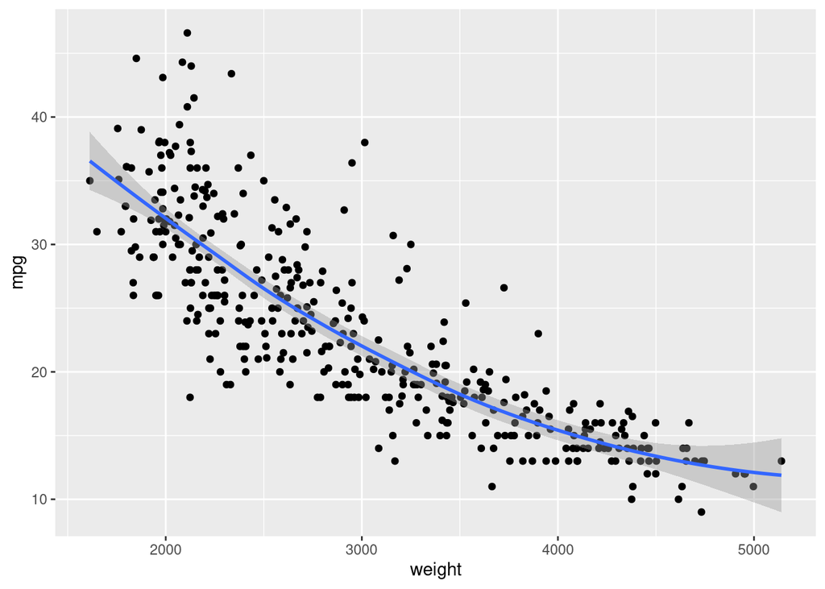

```r
ScatterPlot(df.A, weight, mpg)
```

```r
cor(weight, mpg)
```

```
## [1] -0.8322442
```

The relationship between weight and mpg is negative and looks pretty linear.

## Modeling —-

From our variables displacement, horsepower and weight they seem all good variables to explain mpg.

### Setting up Rjags —-

#### Uninformative priors —-

This model show uninformative priors.

```r
df.A.model <- "model {
#Model
for (i in 1:length(Y)) {
Y[i] ~ dnorm(mu[i], s^(-2))
mu[i] <- b0 + b1*x1[i] + b2*x2[i] + b3*x3[i]
}

#Prior
b0 ~ dnorm(0, 200^(-2))
b1 ~ dnorm(0, 200^(-2))
b2 ~ dnorm(0, 200^(-2))
b3 ~ dnorm(0, 200^(-2))

s ~ dunif(0,200)

}"
```

#### Data —-

```r
A.data <- list(
  Y = mpg,
  x1 = displacement,
  x2 = horsepower,
  x3 = weight
)
```

#### Initial —-

Using the initial coef from a linear model to set the intial values

```r
A.n.chains <- 3
A.inital.coef <- coef(df.A.lm <- lm(mpg ~ displacement + horsepower + weight))
A.inits = list()
for(i in 1:A.n.chains){
  A.inits[[i]] <- list(b0 = rnorm(1,A.inital.coef['(Intercept)'],200),
                     b1 = rnorm(1,A.inital.coef["displacement"], 200),
                     b2 = rnorm(1,A.inital.coef["horsepower"], 200),
                     b3 = rnorm(1,A.inital.coef["weight"], 200),
                     .RNG.name = "base::Wichmann-Hill",
                     .RNG.seed = 10)
}
```

### Running JAGS —-

Is n.adapt the same as burn in?

```r
df.A.jags <- jags.model(
  file = textConnection(df.A.model),
  data = A.data,
  inits = A.inits,
  n.chains = A.n.chains,
  n.adapt=0
)
```

### Drawing from posterior

```r
A.n.iter <- 100000

df.A.sim <- coda.samples(
  model = df.A.jags,
  variable.names = c("b0", "b1", 'b2', 'b3', 's'),
  n.iter = A.n.iter
)
```

```
## NOTE: Stopping adaptation
```

### Determining Burnin —-

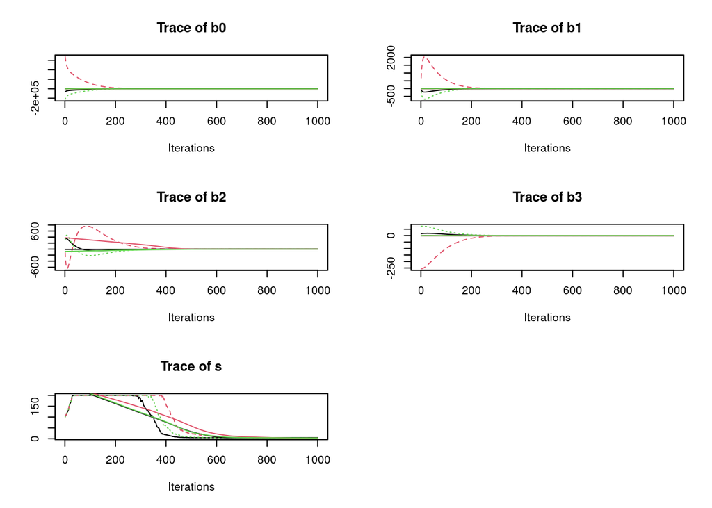

```r
#Seems 1000 is a good burnin time
plot(window(df.A.sim, 1,1000), density = F)
```

```r
df.A.sim.nb <- window(df.A.sim, 1000)
```

### Diagnostics —-

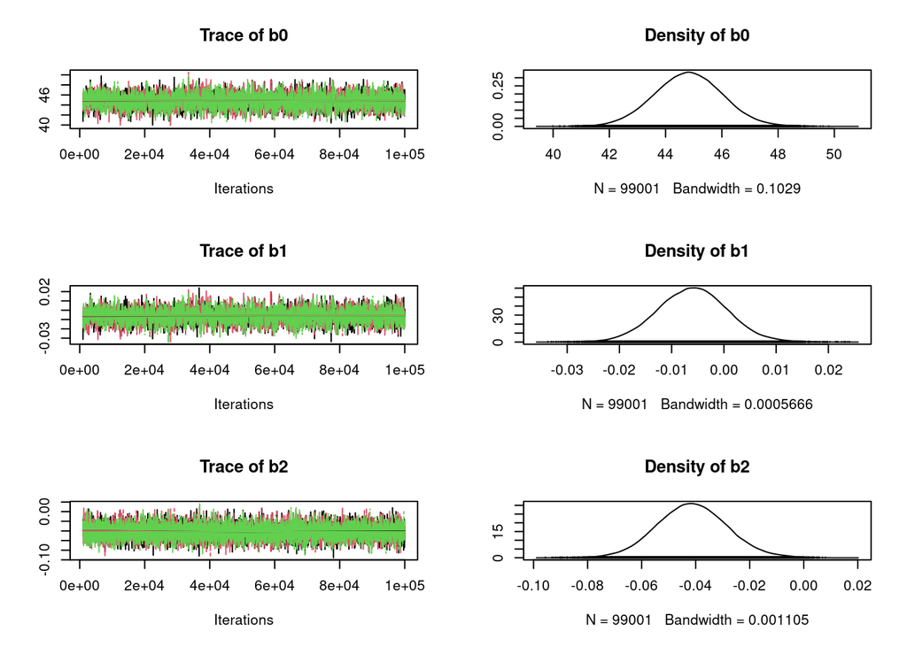

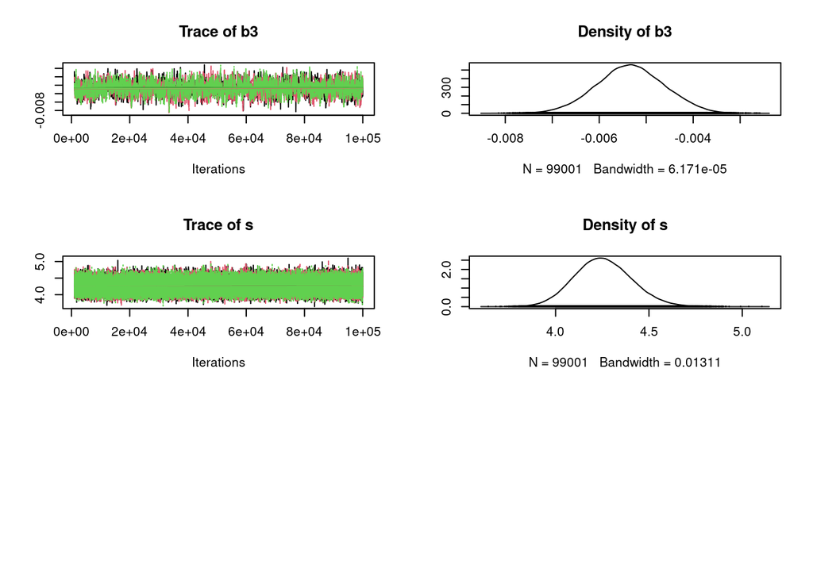

```r
plot(df.A.sim.nb)
```

I am curious if it looks better just because it has more points so can’t see the detail.

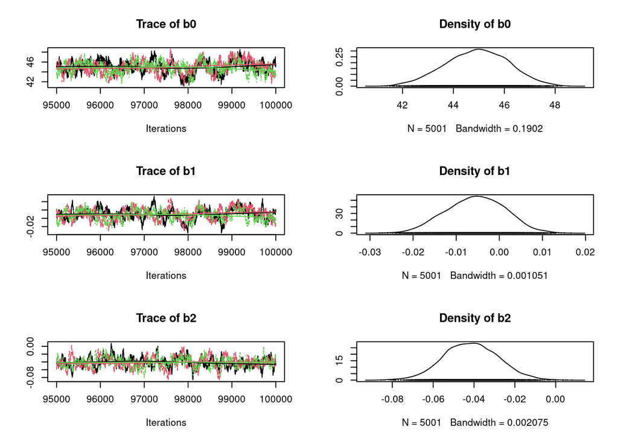

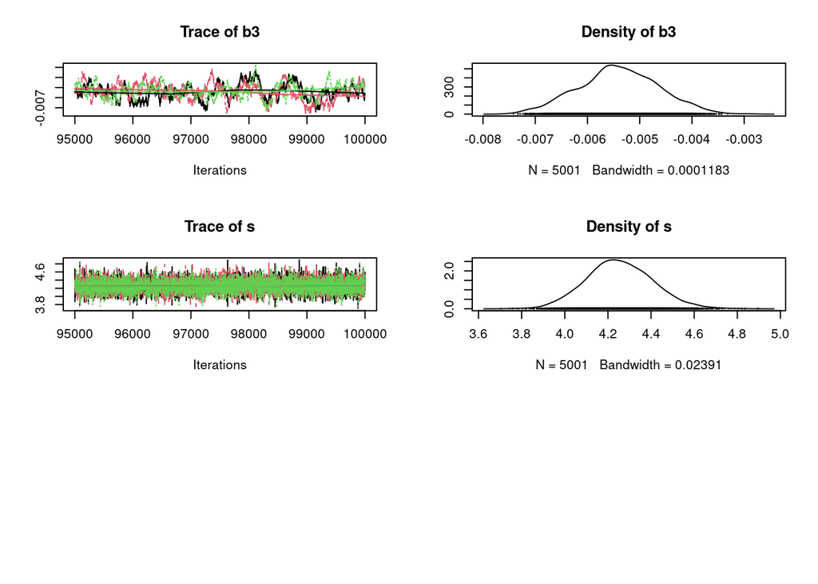

```r
plot(window(df.A.sim.nb, A.n.iter-5000))
```

When looking at the small window seems okay.

We see the coefficients are negative which agree with our preliminary data.

```r
summary(df.A.sim.nb)
```

```
##
## Iterations = 1000:1e+05
## Thinning interval = 1
## Number of chains = 3
## Sample size per chain = 99001
##
## 1. Empirical mean and standard deviation for each variable,
##    plus standard error of the mean:
##
##         Mean        SD  Naive SE Time-series SE
## b0 44.810943 1.2073154 2.215e-03      2.659e-02
## b1 -0.006015 0.0066504 1.220e-05      1.422e-04
## b2 -0.041273 0.0129945 2.384e-05      2.171e-04
## b3 -0.005335 0.0007251 1.331e-06      1.791e-05
## s   4.255586 0.1538231 2.823e-04      3.211e-04
##
## 2. Quantiles for each variable:
##
##         2.5%       25%       50%       75%     97.5%
## b0 42.444434 43.998344 44.810561 45.618054 47.198248
## b1 -0.019068 -0.010490 -0.005988 -0.001585  0.007126
## b2 -0.066449 -0.050045 -0.041414 -0.032685 -0.015115
## b3 -0.006765 -0.005817 -0.005337 -0.004847 -0.003920
## s   3.967313  4.150135  4.250443  4.356207  4.570975
```

```r
gelman.diag(df.A.sim.nb)
```

```
## Potential scale reduction factors:
##
##    Point est. Upper C.I.
## b0          1          1
## b1          1          1
## b2          1          1
## b3          1          1
## s           1          1
##
## Multivariate psrf
##
## 1
```

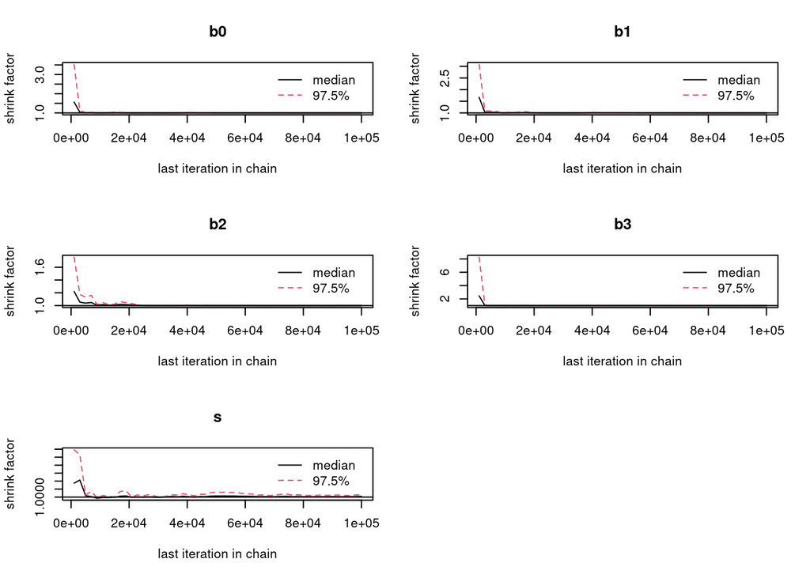

```r
gelman.plot(df.A.sim.nb)
```

The values are less than 1.1

### Inference —-

```r
df.A.sim.post <- data.frame(df.A.sim.nb[[1]])
```

Density for each parameter

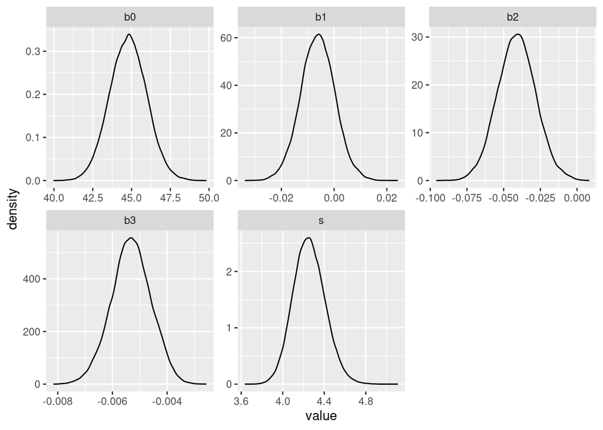

```r
df.A.sim.post %>%
  gather() %>%
  ggplot(mapping = aes(value))+
  facet_wrap(~key, scales = "free")+
  geom_density()
```

95 % Credible interval

```r
df.A.sim.post %>%
  gather() %>%
  group_by(key) %>%
  summarise(mean = mean(value),
            q2.5= quantile(value, .025),
            q97.5 = quantile(value, .975))
```

```
## # A tibble: 5 x 4
##   key       mean     q2.5    q97.5
##   <chr>    <dbl>    <dbl>    <dbl>
## 1 b0    44.8     42.5     47.1
## 2 b1    -0.00619 -0.0190   0.00679
## 3 b2    -0.0411  -0.0666  -0.0151
## 4 b3    -0.00532 -0.00677 -0.00392
## 5 s      4.26     3.97     4.57
```

Interestingly the b1 variable changes from positive to negative.

```r
mean(df.A.sim.post$b1 > 0)
```

```
## [1] 0.1679074
```

```r
summary(df.A.lm)
```

```
##
## Call:
## lm(formula = mpg ~ displacement + horsepower + weight)
##
## Residuals:
##      Min       1Q   Median       3Q      Max
## -11.3347  -2.8028  -0.3402   2.2037  16.2409
##
## Coefficients:
##                Estimate Std. Error t value Pr(>|t|)
## (Intercept)  44.8559357  1.1959200  37.507  < 2e-16 ***
## displacement -0.0057688  0.0065819  -0.876  0.38132
## horsepower   -0.0416741  0.0128139  -3.252  0.00125 **
## weight       -0.0053516  0.0007124  -7.513 4.04e-13 ***
## ---
## Signif. codes:  0 '***' 0.001 '**' 0.01 '*' 0.05 '.' 0.1 ' ' 1
##
## Residual standard error: 4.241 on 388 degrees of freedom
## Multiple R-squared:  0.707,  Adjusted R-squared:  0.7047
## F-statistic:   312 on 3 and 388 DF,  p-value: < 2.2e-16
```

When comparing with a standard linear regression we can see that b1(displacement) is not significant

Correlation of parameters

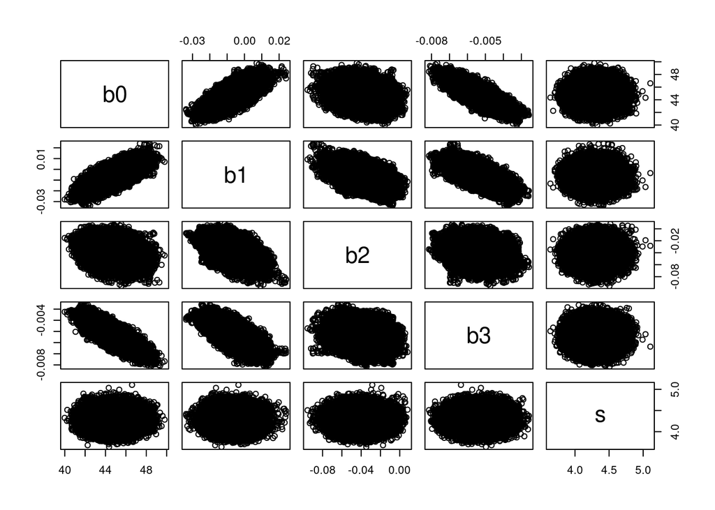

```r
pairs(df.A.sim.post)
```

```r
cor(df.A.sim.post)
```

```
##              b0           b1          b2            b3             s
## b0  1.000000000  0.733744806 -0.22888246 -0.8174942678 -0.0025109505
## b1  0.733744806  1.000000000 -0.47012734 -0.6932017830 -0.0057228788
## b2 -0.228882459 -0.470127343  1.00000000 -0.2289251712  0.0080312402
## b3 -0.817494268 -0.693201783 -0.22892517  1.0000000000 -0.0004849883
## s  -0.002510951 -0.005722879  0.00803124 -0.0004849883  1.0000000000
```

There seems to be multicolinearity which we saw already.